# Week 8 Ex Solution

Katz

3/8/2021

For this week’s exercise, we will be looking at differences in students’ SAT scores.

We will simulate data that we might have where a dependent samples t-test would be appropriate.

We are going to simulate the scenario where we have student SAT scores on both the verbal section and math section.

```r
samp_size <- 1000

student_id <- seq(samp_size)
sat_verbal <- round(rnorm(n = samp_size, mean = 620, sd = 55), 0)
sat_math <- round(rnorm(n = samp_size, mean = 700, sd = 40), 0)

sat_verbal_capped <- modify(.x = sat_verbal, .f = ~ min(800, .x))
sat_math_capped <- modify(.x = sat_math, .f = ~min(800, .x))

sat_df <- tibble(id = student_id,
                 verbal = sat_verbal_capped,
                 math = sat_math_capped)
```

Up to now, we only simulated data and stored it in a dataframe called sat_df.

For your first step, try visualizing the verbal and math scores using histograms.

1. Verbal scores

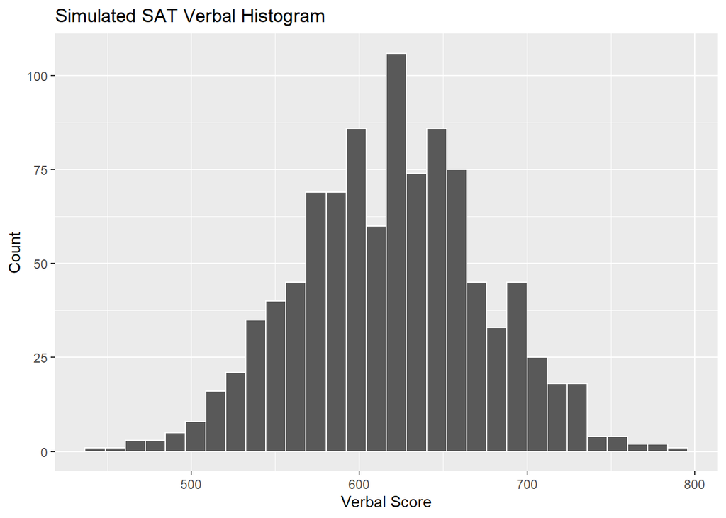

```r
sat_df %>% ggplot(aes(x = verbal)) +
  geom_histogram(color = "white") +
  labs(title = "Simulated SAT Verbal Histogram",
       x = "Verbal Score",
       y = "Count")
```

2. Math scores

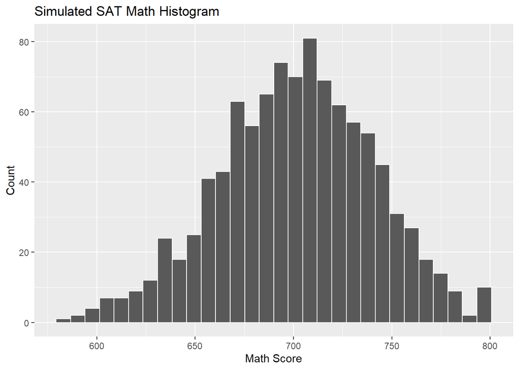

```r
sat_df %>% ggplot(aes(x = math)) +
  geom_histogram(color = "white") +
  labs(title = "Simulated SAT Math Histogram",
       x = "Math Score",
       y = "Count")
```

Alternatively, try to plot these together by either making a long data set or just overlaying histograms and modifying transparency (the alpha parameter).

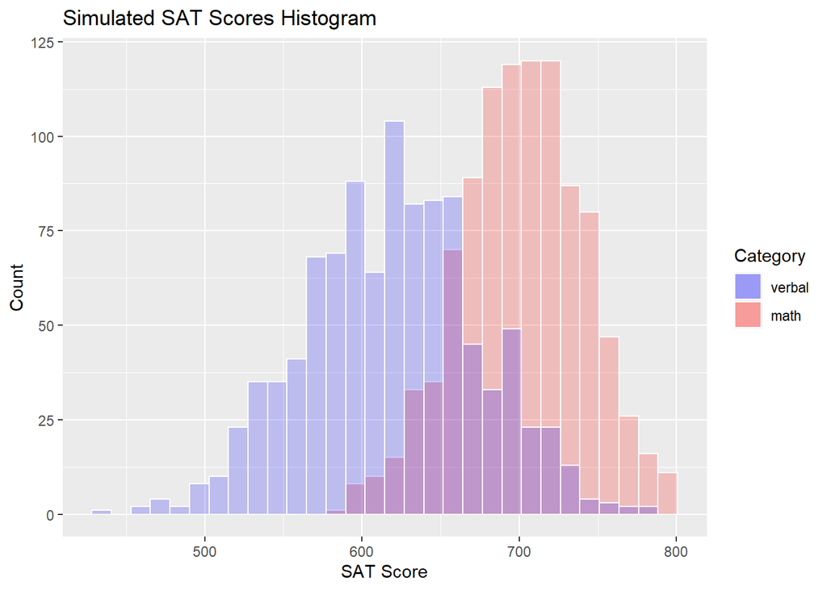

```r
sat_df %>% ggplot() +
  geom_histogram(aes(x = math, fill = "red"), color = "white", alpha = 0.2) +
  labs(title = "Simulated SAT Scores Histogram",
       x = "SAT Score",
       y = "Count") +
  geom_histogram(aes(x = verbal, fill = "blue"), color = "white", alpha = 0.2) +
  scale_fill_manual(name = "Category", values = c("blue", "red"), labels = c("verbal", "math"))
```

You should also try doing this with a boxplot. I give you the code for this first version since it involves a `pivot_longer()`, but you should see if you can replicate it for the next rounds on your own.

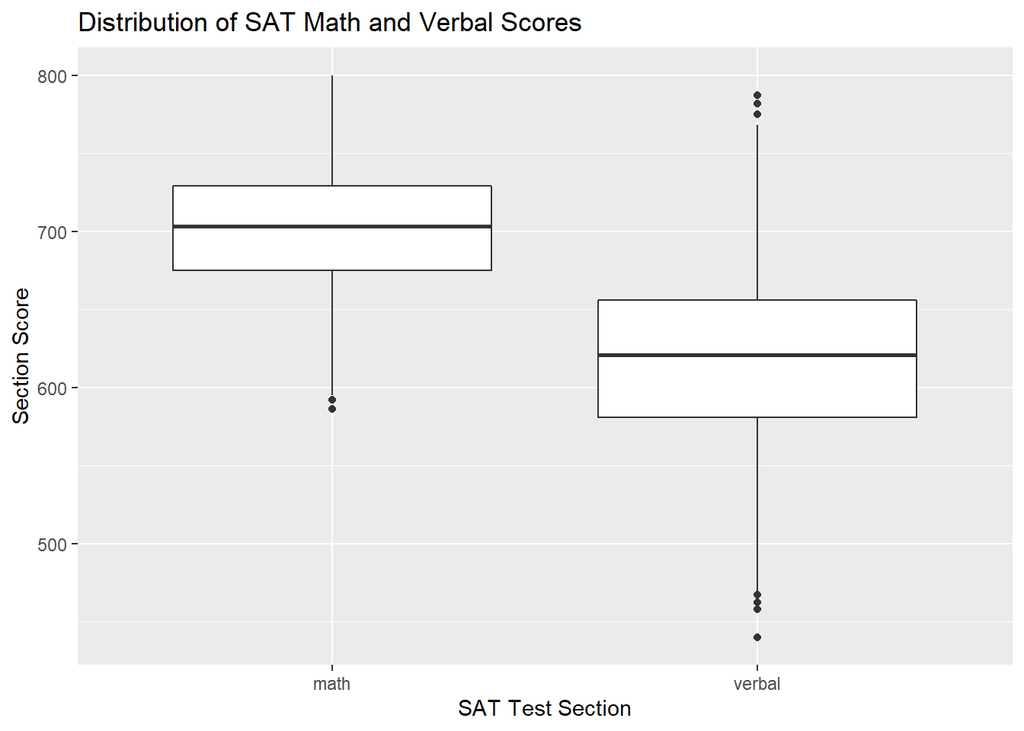

```r
sat_df %>%
  pivot_longer(cols = c("verbal", "math"),
               names_to = "variable",
               values_to = "score") %>%
  ggplot(aes(x = variable, y = score)) +
  geom_boxplot() +
  labs(x = "SAT Test Section",
       y = "Section Score",
       title = "Distribution of SAT Math and Verbal Scores")
```

Looking at the histogram, we can see that there appears to be a systematic difference in the scores. Running a t-test will help us see if that initial observation is statistically correct.

Since we will be comparing verbal and math scores for each student, this will be a dependent samples (or paired samples) t-test.

```r
sat_t_test <- t.test(sat_df$verbal, sat_df$math, paired = TRUE) # don't forget to add: paired = TRUE
# now look at the results
sat_t_test
```

```
##
##  Paired t-test
##
## data:  sat_df$verbal and sat_df$math
## t = -37.41, df = 999, p-value < 2.2e-16
## alternative hypothesis: true difference in means is not equal to 0
## 95 percent confidence interval:
##  -86.40651 -77.79349
## sample estimates:
## mean of the differences
##                   -82.1
```

```r
(t <- sat_t_test$statistic[[1]]) # wrapping this in parentheses prints out the value of t at the same time that it stores the value of t
```

```
## [1] -37.4104
```

```r
(df <- sat_t_test$parameter[[1]])
```

```
## [1] 999
```

```r
(r <- sqrt(t^2/(t^2 + df)))
```

```
## [1] 0.7638693
```

```r
round(r,3)
```

```
## [1] 0.764
```

```r
r^2
```

```
## [1] 0.5834963
```

We see there was a statistically significant difference, but now let’s try changing the distributions and see what happens.

### Round 2

First, we’ll change make the means very close together and see how sensitive the test is to that

```r
samp_size <- 1000

student_id_2 <- seq(samp_size)
sat_verbal_2 <- round(rnorm(n = samp_size, mean = 690, sd = 55), 0)
sat_math_2 <- round(rnorm(n = samp_size, mean = 700, sd = 40), 0)

# let's cap the simulated scores at 800
sat_verbal_2_capped <- modify(.x = sat_verbal_2, .f = ~ min(800, .x))
sat_math_2_capped <- modify(.x = sat_math_2, .f = ~min(800, .x))


sat_df_2 <- tibble(id = student_id,
                 verbal = sat_verbal_2_capped,
                 math = sat_math_2_capped)
```

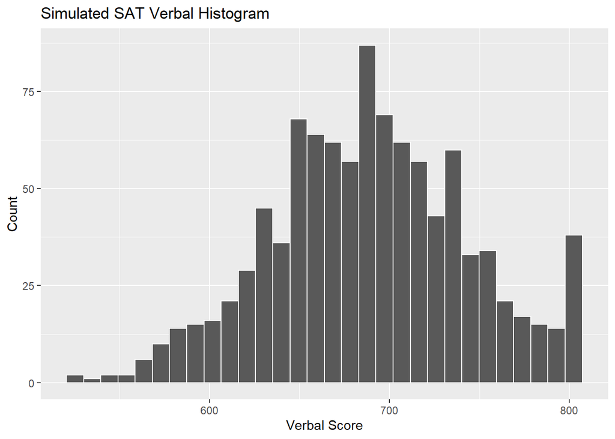

```r
sat_df_2 %>% ggplot(aes(x = verbal)) +
  geom_histogram(color = "white") +
  labs(title = "Simulated SAT Verbal Histogram",
       x = "Verbal Score",
       y = "Count")
```

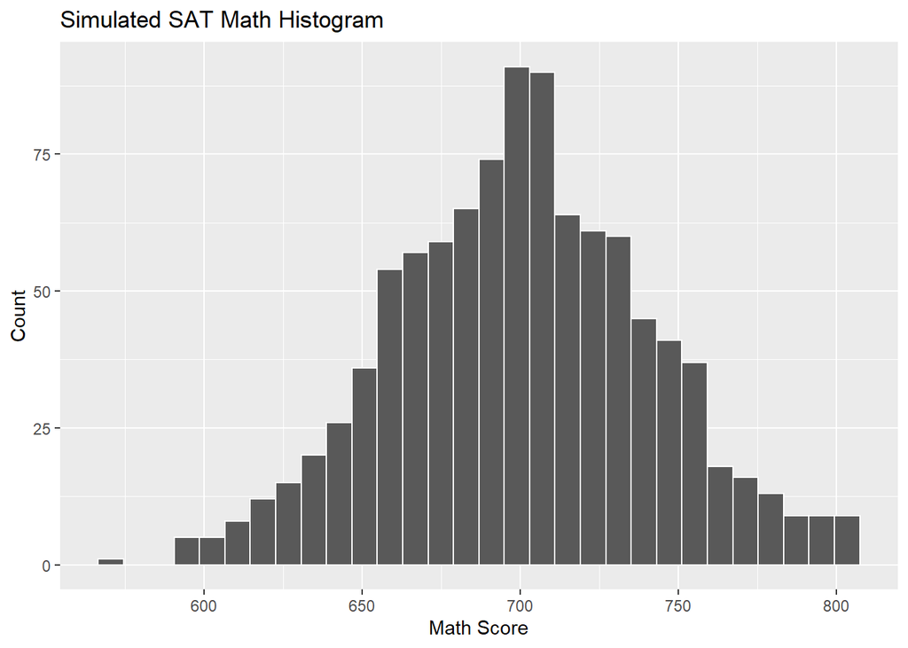

```r
sat_df_2 %>% ggplot(aes(x = math)) +
  geom_histogram(color = "white") +
  labs(title = "Simulated SAT Math Histogram",
       x = "Math Score",
       y = "Count")
```

Alternatively, we could plot these together by either making a long data set or just overlaying histograms and modifying transparency (the alpha parameter).

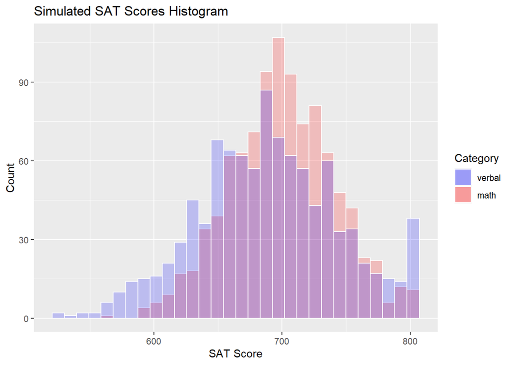

```r
sat_df_2 %>% ggplot() +
  geom_histogram(aes(x = math, fill = "red"), color = "white", alpha = 0.2) +
  labs(title = "Simulated SAT Scores Histogram",
       x = "SAT Score",
       y = "Count") +
  geom_histogram(aes(x = verbal, fill = "blue"), color = "white", alpha = 0.2) +
  scale_fill_manual(name = "Category", values = c("blue", "red"), labels = c("verbal", "math"))
```

You should also try doing this with a boxplot.

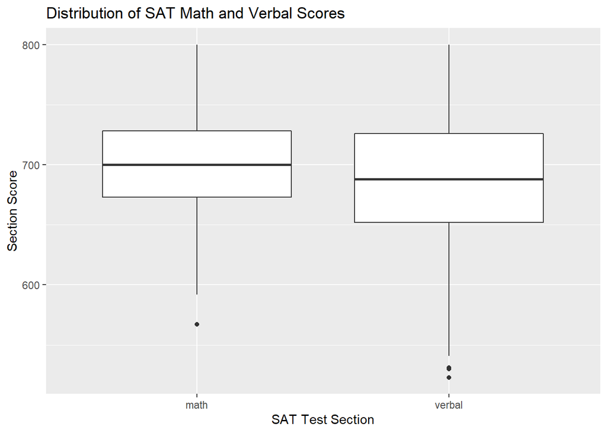

```r
sat_df_2 %>%
  pivot_longer(cols = c("verbal", "math"),
               names_to = "variable",
               values_to = "score") %>%
  ggplot(aes(x = variable, y = score)) +
  geom_boxplot() +
  labs(x = "SAT Test Section",
       y = "Section Score",
       title = "Distribution of SAT Math and Verbal Scores")
```

Looking at the histogram, we can see that there appears to be a systematic difference in the scores. Running a t-test will help us see if that initial observation is statistically correct.

Since we will be comparing verbal and math scores for each student, this will be a dependent samples (or paired samples) t-test

```r
sat_t_test_2 <- t.test(sat_df_2$verbal, sat_df_2$math, paired = TRUE) # don't forget to add: paired = TRUE
# now look at the results
sat_t_test_2
```

```
##
##  Paired t-test
##
## data:  sat_df_2$verbal and sat_df_2$math
## t = -5.2532, df = 999, p-value = 1.827e-07
## alternative hypothesis: true difference in means is not equal to 0
## 95 percent confidence interval:
##  -15.776634  -7.195366
## sample estimates:
## mean of the differences
##                 -11.486
```

Calculate an effect size. Remember that $r = \sqrt{\frac{t^2}{t^2 + df}}$

```r
(t <- sat_t_test_2$statistic[[1]]) # wrapping this in parentheses prints out the value of t at the same time that it stores the value of t
```

```
## [1] -5.253176
```

```r
(df <- sat_t_test_2$parameter[[1]])
```

```
## [1] 999
```

```r
(r <- sqrt(t^2/(t^2 + df)))
```

```
## [1] 0.1639541
```

```r
round(r,3)
```

```
## [1] 0.164
```

```r
r^2
```

```
## [1] 0.02688094
```

### Round 3

Let’s try a third test - this time we’ll change the sample size to be 25 students rather than 1000

```r
samp_size <- 25

student_id_3 <- seq(samp_size)
sat_verbal_3 <- round(rnorm(n = samp_size, mean = 690, sd = 55), 0)
sat_math_3 <- round(rnorm(n = samp_size, mean = 700, sd = 40), 0)

# cap the scores at 800
sat_verbal_3_capped <- modify(.x = sat_verbal_3, .f = ~ min(800, .x))
sat_math_3_capped <- modify(.x = sat_math_3, .f = ~min(800, .x))



sat_df_3 <- tibble(id = student_id_3,
                 verbal = sat_verbal_3_capped,
                 math = sat_math_3_capped)
```

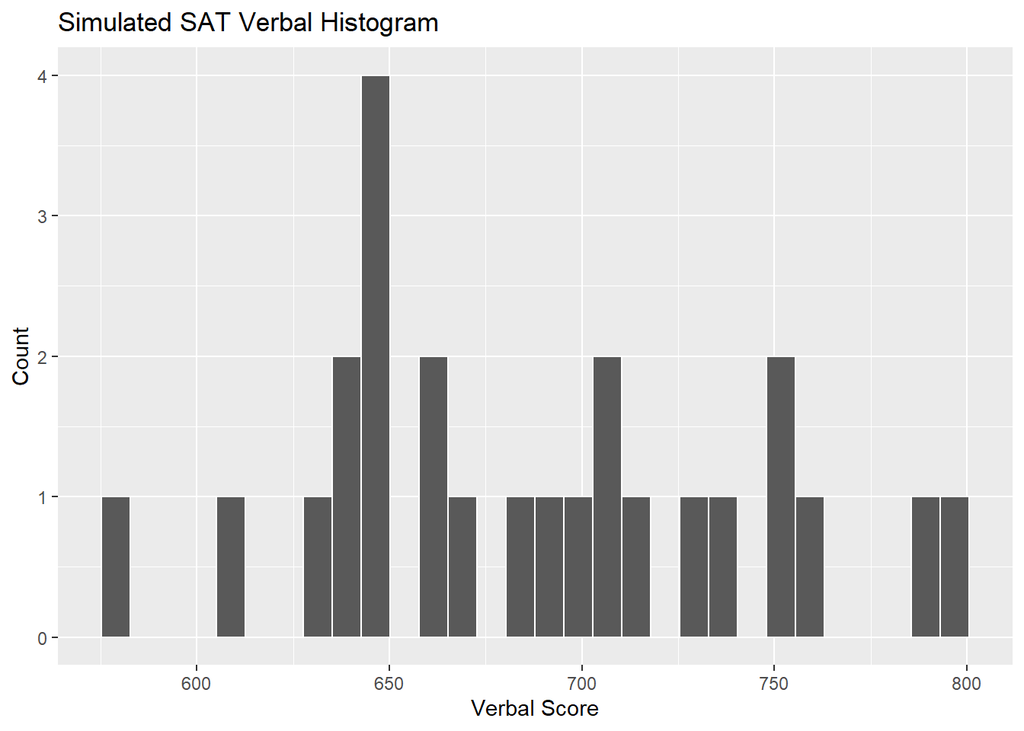

```r
sat_df_3 %>% ggplot(aes(x = verbal)) +
  geom_histogram(color = "white") +
  labs(title = "Simulated SAT Verbal Histogram",
       x = "Verbal Score",
       y = "Count")
```

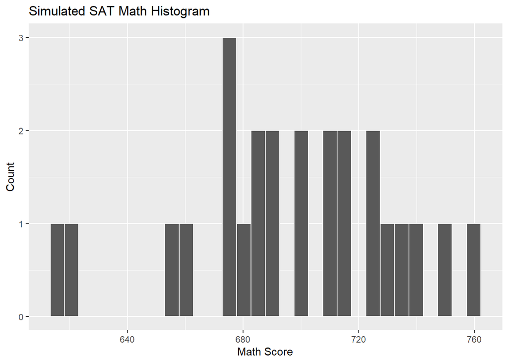

```r
sat_df_3 %>% ggplot(aes(x = math)) +
  geom_histogram(color = "white") +
  labs(title = "Simulated SAT Math Histogram",
       x = "Math Score",
       y = "Count")
```

Alternatively, we could plot these together by either making a long data set or just overlaying histograms and modifying transparency (the alpha parameter)

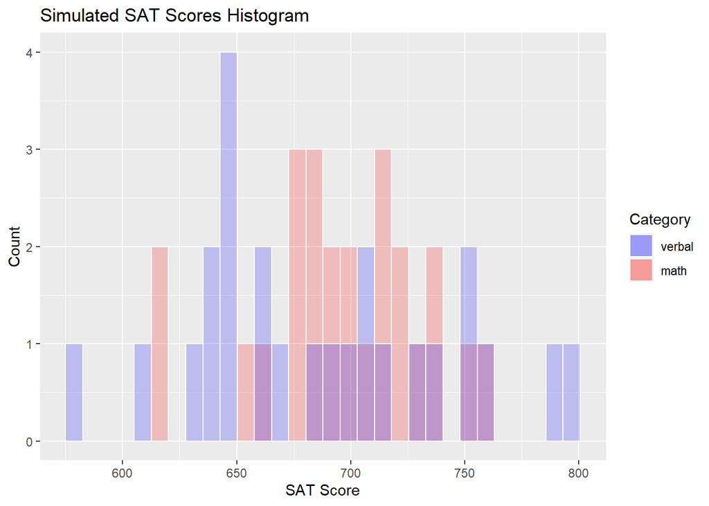

```r
sat_df_3 %>% ggplot() +
  geom_histogram(aes(x = math, fill = "red"), color = "white", alpha = 0.2) +
  labs(title = "Simulated SAT Scores Histogram",
       x = "SAT Score",
       y = "Count") +
  geom_histogram(aes(x = verbal, fill = "blue"), color = "white", alpha = 0.2) +
  scale_fill_manual(name = "Category", values = c("blue", "red"), labels = c("verbal", "math"))
```

Try making a boxplot instead of histogram.

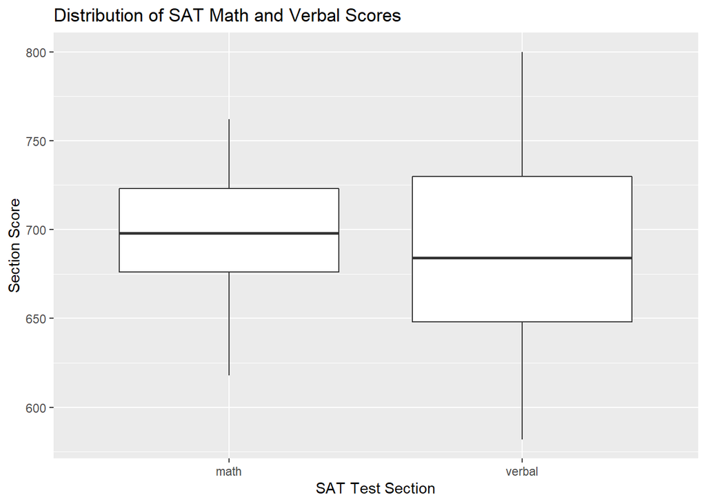

```r
sat_df_3 %>%
  pivot_longer(cols = c("verbal", "math"),
               names_to = "variable",
               values_to = "score") %>%
  ggplot(aes(x = variable, y = score)) +
  geom_boxplot() +
  labs(x = "SAT Test Section",
       y = "Section Score",
       title = "Distribution of SAT Math and Verbal Scores")
```

```r
sat_t_test_3 <- t.test(sat_df_3$verbal, sat_df_3$math, paired = TRUE) # don't forget to add: paired = TRUE
# now look at the results
sat_t_test_3
```

```
##
##  Paired t-test
##
## data:  sat_df_3$verbal and sat_df_3$math
## t = -0.63093, df = 24, p-value = 0.5341
## alternative hypothesis: true difference in means is not equal to 0
## 95 percent confidence interval:
##  -37.0741  19.7141
## sample estimates:
## mean of the differences
##                   -8.68
```

Calculate an effect size. Remember that $r = \sqrt{\frac{t^2}{t^2 + df}}$

```r
(t <- sat_t_test_3$statistic[[1]]) # wrapping this in parentheses prints out the value of t at the same time that it stores the value of t
```

```
## [1] -0.6309282
```

```r
(df <- sat_t_test_3$parameter[[1]])
```

```
## [1] 24
```

```r
(r <- sqrt(t^2/(t^2 + df)))
```

```
## [1] 0.1277327
```

```r
round(r,3)
```

```
## [1] 0.128
```

```r
r^2
```

```
## [1] 0.01631565
```

### Round 4

Now we see that the statistically significant difference is gone. How about if we go back to having a large difference in the means

```r
samp_size <- 25

student_id_4 <- seq(samp_size)
sat_verbal_4 <- round(rnorm(n = samp_size, mean = 620, sd = 55), 0)
sat_math_4 <- round(rnorm(n = samp_size, mean = 700, sd = 40), 0)

#cap the scores at 800
sat_verbal_4_capped <- modify(.x = sat_verbal_4, .f = ~ min(800, .x))
sat_math_4_capped <- modify(.x = sat_math_4, .f = ~min(800, .x))


sat_df_4 <- tibble(id = student_id_4,
                   verbal = sat_verbal_4_capped,
                   math = sat_math_4_capped)
```

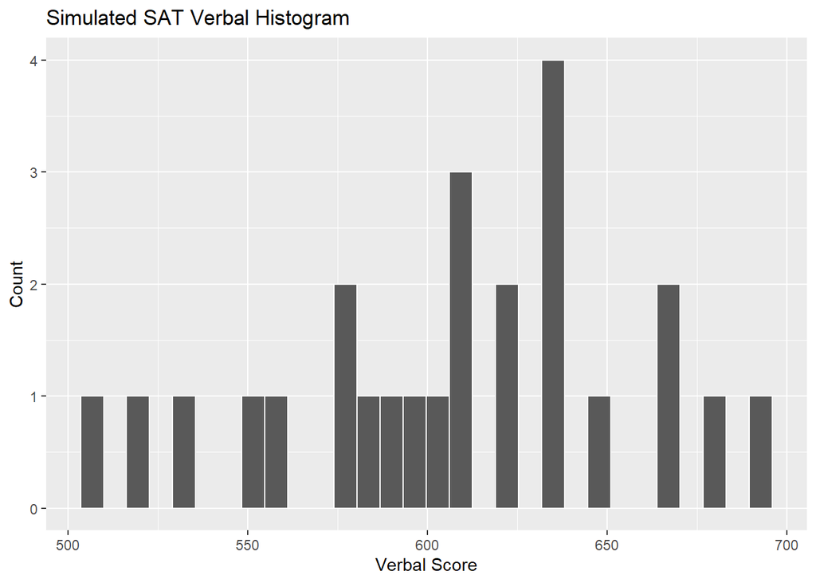

```r
# visualize the distributions of scores
sat_df_4 %>% ggplot(aes(x = verbal)) +
  geom_histogram(color = "white") +
  labs(title = "Simulated SAT Verbal Histogram",
       x = "Verbal Score",
       y = "Count")
```

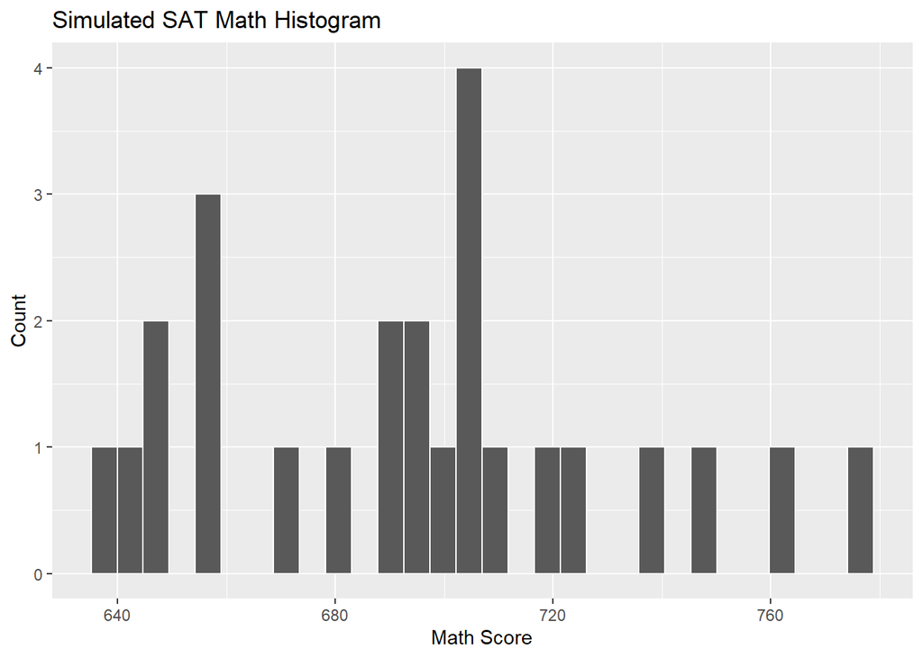

```r
sat_df_4 %>% ggplot(aes(x = math)) +
  geom_histogram(color = "white") +
  labs(title = "Simulated SAT Math Histogram",
       x = "Math Score",
       y = "Count")
```

Alternatively, we could plot these together by either making a long data set or just overlaying histograms and modifying transparency (the alpha parameter)

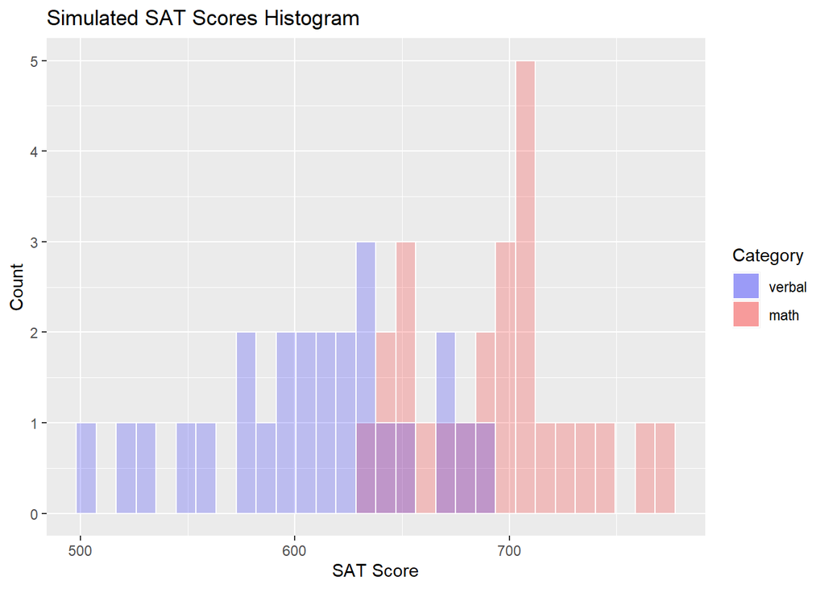

```r
sat_df_4 %>% ggplot() +
  geom_histogram(aes(x = math, fill = "red"), color = "white", alpha = 0.2) +
  labs(title = "Simulated SAT Scores Histogram",
       x = "SAT Score",
       y = "Count") +
  geom_histogram(aes(x = verbal, fill = "blue"), color = "white", alpha = 0.2) +
  scale_fill_manual(name = "Category", values = c("blue", "red"), labels = c("verbal", "math"))
```

Try a boxplot instead

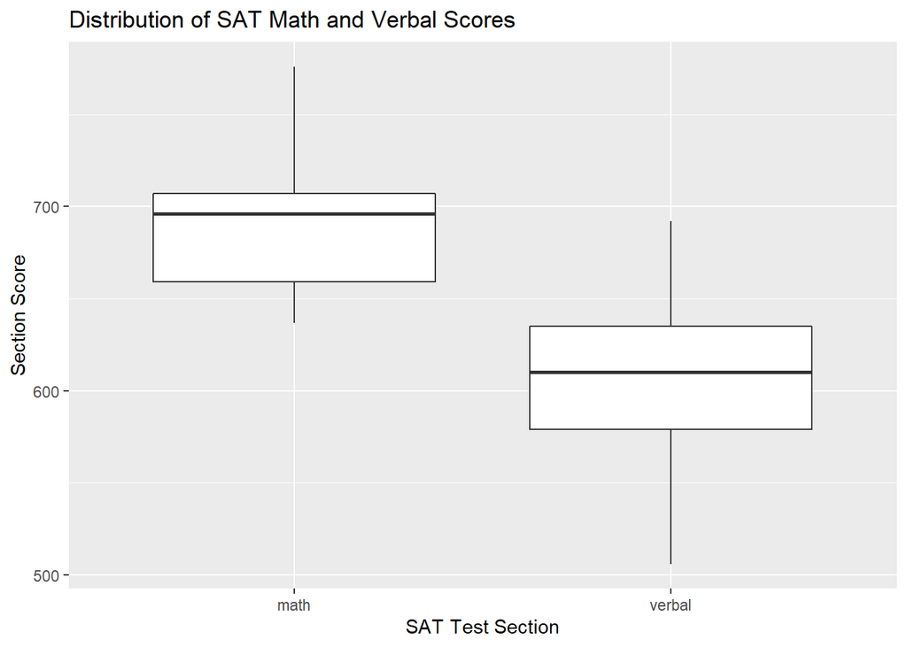

```r
sat_df_4 %>%
  pivot_longer(cols = c("verbal", "math"),
               names_to = "variable",
               values_to = "score") %>%
  ggplot(aes(x = variable, y = score)) +
  geom_boxplot() +
  labs(x = "SAT Test Section",
       y = "Section Score",
       title = "Distribution of SAT Math and Verbal Scores")
```

Looking at the histogram, we can see that there appears to be a systematic difference in the scores. Running a t-test will help us see if that initial observation is statistically correct. Since we will be comparing verbal and math scores for each student, this will be a dependent samples (or paired samples) t-test

```r
sat_t_test_4 <- t.test(sat_df_4$math, sat_df_4$verbal, paired = TRUE) # don't forget to add: paired = TRUE
# now look at the results
sat_t_test_4
```

```
##
##  Paired t-test
##
## data:  sat_df_4$math and sat_df_4$verbal
## t = 8.2579, df = 24, p-value = 1.792e-08
## alternative hypothesis: true difference in means is not equal to 0
## 95 percent confidence interval:
##   65.886 109.794
## sample estimates:
## mean of the differences
##                   87.84
```

We should see that the t-test will pick up differences between means if there is a sufficiently large difference.

Calculate an effect size. Remember that $r = \sqrt{\frac{t^2}{t^2 + df}}$

```r
(t <- sat_t_test_4$statistic[[1]]) # wrapping this in parentheses prints out the value of t at the same time that it stores the value of t
```

```
## [1] 8.257852
```

```r
(df <- sat_t_test_4$parameter[[1]])
```

```
## [1] 24
```

```r
(r <- sqrt(t^2/(t^2 + df)))
```

```
## [1] 0.8600431
```

```r
round(r,3)
```

```
## [1] 0.86
```

```r
r^2
```

```
## [1] 0.7396741
```